```python
import numpy as np
import matplotlib.pyplot as plt #would like a better plotting library
import scipy
%matplotlib inline
```

NBconvert - set all headings to add an id so i can link to them

# Contents

# t - SNE

## Definition

Given a dataset of N high-dimensional objects $\mathbf{x}_1, \dots, \mathbf{x}_N \in \mathbb{X}$, t-SNE first computes probabilities $p_{ij}$ that are proportional to the similarity of objects $\mathbf{x}_i$ and $\mathbf{x}_j$, as follows:

$$p_{j\mid i} = \frac{\exp(-\lVert\mathbf{x}_i - \mathbf{x}_j\rVert^2 / 2\sigma_i^2)}{\sum_{k \neq i} \exp(-\lVert\mathbf{x}_i - \mathbf{x}_k\rVert^2 / 2\sigma_i^2)} \\ p_{ij} = \frac{p_{j\mid i} + p_{i\mid j}}{2N}$$

The bandwidth of the Gaussian kernels $\sigma_i$, is set in such a way that the perplexity of the conditional distribution equals a predefined perplexity using a binary search. As a result, the bandwidth is adapted to the density of the data: smaller values of \sigma_i are used in denser parts of the data space.

t-SNE aims to learn a d-dimensional map $\mathbf{y}_1, \dots, \mathbf{y}_N$ (with $\mathbf{y}_i \in \mathbb{R}^d$) that reflects the similarities $p_{ij}$ as well as possible. To this end, it measures similarities $q_{ij}$ between two points in the map $\mathbf{y}_i$ and $\mathbf{y}_j$, using a very similar approach. Specifically, $q_{ij}$ is defined as:

$$q_{ij} = \frac{(1 + \lVert \mathbf{y}_i - \mathbf{y}_j\rVert^2)^{-1}}{\sum_{k \neq \ell} (1 + \lVert \mathbf{y}_k - \mathbf{y}_\ell\rVert^2)^{-1}}$$

Herein a heavy-tailed Student-t distribution is used to measure similarities between low-dimensional points in order to allow dissimilar objects to be modeled far apart in the map.

The locations of the points \mathbf{y}_i in the map are determined by minimizing the (non-symmetric) Kullback–Leibler divergence of the distribution Q from the distribution P, that is:

$$ KL(P||Q) = \sum_{i \neq j} p_{ij} \log \frac{p_{ij}}{q_{ij}} $$

The minimization of the Kullback–Leibler divergence with respect to the points $\mathbf{y}_i$ is performed using gradient descent. The result of this optimization is a map that reflects the similarities between the high-dimensional inputs well.

## Motivation

- Find topology of data? It would be nice to ?

## Background

### Metric spaces and distances

need to learn this

### Gaussians

$$ f \left (x\right) = a e^{- { \frac{(x-b)^2 }{ 2 c^2} } }$$

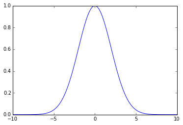

```python
x = np.linspace(-10,10,100)
a = 1 #the height
b = 0 #the x/center position
c = 2 #the width
f = a*np.exp(-((x-b)**2)/(2*(c**2)))
plt.plot(x,f)
```

### Kullback–Leibler divergence

It is also called the relative entropy of P with respect to Q, and written H(P|Q).

$$D_{\mathrm{KL}}(P\|Q) = \sum_i P(i) \, \log\frac{P(i)}{Q(i)}$$

Pictures to explain would be good

## Method

### Cost function

The cost function and derivates - need to derive this here!

$$ \mathbf{C} = \sum_{i} KL(P_i||Q_i) = \sum_{i}\sum_{j} p_{ij} \log \frac{p_{ij}}{q_{ij}} $$$$\frac{\partial \mathbf{C}}{\partial \mathbf{y}} = 2 \sum_{j} (\mathbf{y}_i - \mathbf{y}_j) (p_{ij} - q_{ij} + p_{ji} - q_{ji})$$

### Optimisers

So I guess the questions this raises are;

- how can we find the global maximum?
- how can we get out of local minima? /
  - random jumps,
  - tunnel,
  - use the history of the trajectory (momentum/integral control),
- what are the best methods for optimising surfaces with many local minima? (surely whatever the solution it will be expensive?
  - is this the sort of thing particle swarms are good at?
- how can we reduce the amount of local minima in/on the surface?

To test

- what happens if you init all y at the same position?
- limits as gaussian width tends to 0 and inf

# Questions and thoughts

- The two functions to find p and q should be the same??
- Slower rate of dimensionalty reduction, discrete, continuious. (reminds me of a recursive function?)
- What if the data set is not a bunch of vectors, but matrixies, or other data structures??
- The method needs to reflect the data somehow?
- Are we only allowing orthogonal dimensions? This seems to be quite limiting?? For example, what if we could have dimensions that are curves? So MNIST would be a small number of curve dimensions??
  - so what if we mapped it into non-euclidean grometry and then back?
    - for example - images: we could mapp the pixel intensities into a line segments/curves and them back to a 2d position vector?
    - into the number of turns greater that 270 degrees, then back to a 2d position vector?
  - is this naturally what auto encoders do?
  - what is the difference between a dimension and a feature?
- what is this like? electro magnetic forces acting on particles? gravity acting on particles, a network of forces? ... what techinques have they developed?
- data visualisation technique researchers dont seem to know exactally what they are looking to visualise. we need to rigorously define what it is we are trying to do
- how does this work for unsupervised data?
  - supervised data can ... nice visualisations?
  - unsupervised? we are clustering based on similarities? we can look at how it has group datapoints and see the patterns?

# Resources and references

- [t-SNE on SciKit learn](http://scikit-learn.org/stable/modules/generated/sklearn.manifold.TSNE.html)
- [LAURENS VAN DER MAATEN](https://lvdmaaten.github.io/tsne/)

# Glossary